# Principal Component Analysis

Ageev Vladimir 522

16.10.2016

# Данные

Данные об университетах.

Признаки:

- FICE – Federal ID number
- X – College name
- State
- PPIND – Public/private indicator (public=1, private=2)
- AVRMATH – Average Math SAT score
- AVRVERB – Average Verbal SAT score
- AVRCOMB – Average Combined SAT score
- AVR_ACT – Average ACT score
- MATH_1 / MATH_3 – First / Third quartile - Math SAT
- VERB_1 / VERB_3 – First / Third quartile - Verbal SAT
- ACT_1 / ACT_3 – First / Third quartile - ACT
- APP_REC – Number of applications received
- APP_ACC – Number of applicants accepted
- NEW_STUD – Number of new students enrolled
- NEW_10 / NEW_25 – Pct. new students from top 10% / 25% of H.S. class
- FULLTIME / PARTTIME – Number of fulltime / parttime undergraduates
- IN_STATE – In-state tuition
- OUT_STATE – Out-of-state tuition
- R_B_COST – Room and board costs
- ROOM – Room costs
- BOARD – Board costs
- ADD_FEE – Additional fees
- BOOK – Estimated book costs
- PERSONAL – Estimated personal spending
- PH_D – Pct. of faculty with Ph.D.’s
- TERM_D – Pct. of faculty with terminal degree
- SF_RATIO – Student/faculty ratio
- DONATE – Pct.alumni who donate
- INSTRUCT – Instructional expenditure per student
- GRADUAT – Graduation rate
- SAL_… – salaries
- COMP_ – average compensation
- NUM_ – number of people

Выберем некоторые из этих признаков.

```r
uni <- read.csv2("/Users/Vladimir/Dropbox/Statistics_Autmn_2016/PCA/I.csv")
uni <- uni[,c("X", "PPIND", "NEW10", "R_B_COST","ADD_FEE", "BOOK", "SAL_ALL", "NUM_ALL" ,"APP_ACC", "SF_RATIO", "IN_STATE", "OUT_STAT")]
uni <- na.omit(uni)
head(uni)
```

```
##                      X PPIND NEW10 R_B_COST ADD_FEE BOOK SAL_ALL NUM_ALL APP_ACC SF_RATIO IN_STATE OUT_STAT
## 3 University of Alabam     1    24     5175     291  750     461     406    1260      6.7     2220     4440
## 5 Arizona State Univer     1    24     4850      66  700     489    1383   10308     18.9     1828     7434
## 6 Northern Arizona Uni     1    23     3728      66  620     412     608    4931     21.7     1828     6746
## 7 University of Arizon     1    29     4216      66  620     537    1349   12238     19.6     1828     7434
## 8 University of Arkans     1    25     3300     122  500     452     806    3108     14.8     1932     5028
## 9 California Institute     2    98     5051     210  735     866     257     507      6.5    16695    16695
```

```r
p <- ncol(uni) - 2
```

## График собственных чисел

Воспользуемся функцией dudi.pca. По умолчанию производится PCA с корреляционной матрицей.

```r
pca <- dudi.pca(uni[,3:ncol(uni)], scannf = FALSE, nf = p)
```

Воспользуемся “правилом сломанной трости”

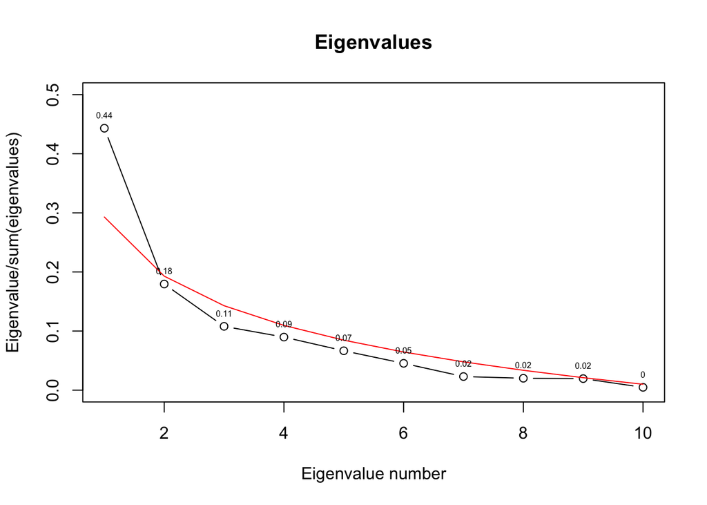

```r
EL <- sapply(1:(p), function(i){
  1/(p) * sum(1/(i:(p)))
})

plot(pca$eig/(p),  main = "Eigenvalues",  ylab = "Eigenvalue/sum(eigenvalues)", xlab = "Eigenvalue number", type = "b", ylim = c(0,0.5))
lines(EL, col = "red")
text(pca$eig/p, labels =  round(pca$eig/(p), digits = 2), cex= 0.5, pos=3)
```

Правило рекомендует брать только одну главную компоненту, но мы возьмем две так как они объясняют больше половины дисперсии.

Из графика можно понять, что первые две главные компоненты объясняют большую часть дисперсии. То же самое можно увидеть в следующей таблице.

```r
summary(pca)
```

```
## Class: pca dudi
## Call: dudi.pca(df = uni[, 3:ncol(uni)], scannf = FALSE, nf = p)
##
## Total inertia: 10
##
## Eigenvalues:
##     Ax1     Ax2     Ax3     Ax4     Ax5
##  4.4317  1.7957  1.0796  0.8979  0.6664
##
## Projected inertia (%):
##     Ax1     Ax2     Ax3     Ax4     Ax5
##  44.317  17.957  10.796   8.979   6.664
##
## Cumulative projected inertia (%):
##     Ax1   Ax1:2   Ax1:3   Ax1:4   Ax1:5
##   44.32   62.27   73.07   82.05   88.71
##
## (Only 5 dimensions (out of 10) are shown)
```

Первые 2 главных компонент объясняют ~62% дисперсии.

## Собственные вектора

Посмотрим на первые 2 собственных вектора (у нас обозначались как $U_i$) корреляционной матрицы:

```r
pca$c1[,1:2]
```

```
##                  CS1         CS2
## NEW10    -0.36564738  0.13452988
## R_B_COST -0.39765980  0.09021199
## ADD_FEE   0.02396789  0.31743203
## BOOK     -0.01762990 -0.17889063
## SAL_ALL  -0.36849376  0.30896111
## NUM_ALL   0.14262532  0.60462878
## APP_ACC   0.14696589  0.60824165
## SF_RATIO  0.36924960  0.06752500
## IN_STATE -0.44838857 -0.03556184
## OUT_STAT -0.43835741  0.06467970
```

Первую компоненту можно проинтерпретировать как качество ВУЗа или его престижность.

Вторую компоненту можно проинтерпретировать как размер ВУЗа.

## Диаграммы факторных весов

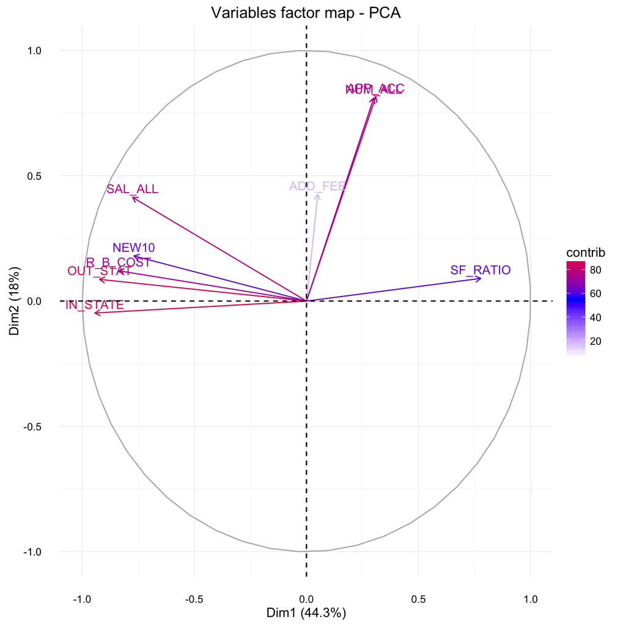

```r
fviz_pca_var(pca, col.var = "contrib")+
scale_color_gradient2(low="white", mid="blue",
      high="red", midpoint=55) + theme_minimal()
```

Если хочется понять насколько ГК описывают данные, можно посмотреть на длины стрелок выше или на barplot корреляций старых признаков с новыми:

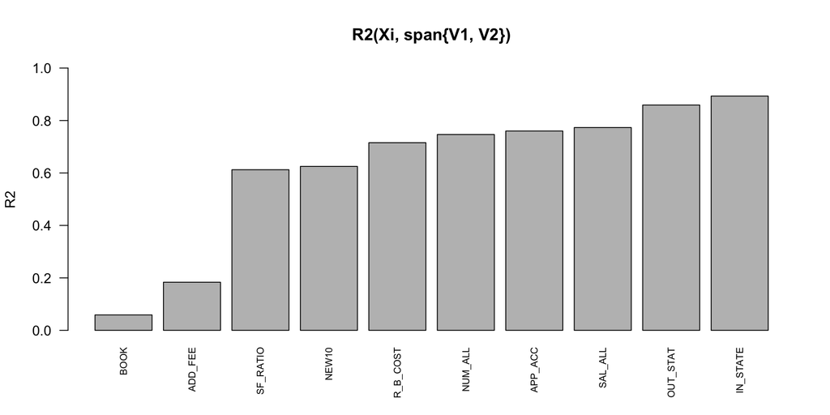

```r
r.sqr <- apply(pca$co[,1:2],1, function(x){
  sum(x^2)
})
r.sqr <- sort(r.sqr)
barplot(r.sqr, ylab = "R2", xlab = "", main = "R2(Xi, span{V1, V2})", ylim = c(0,1), names.arg = names(r.sqr), las = 2, cex.names = 0.7)
```

## График нормированных значений главных компонент

Построим на двумерный график нормированных значений главных компонент (у нас обозначались как $V_i$).

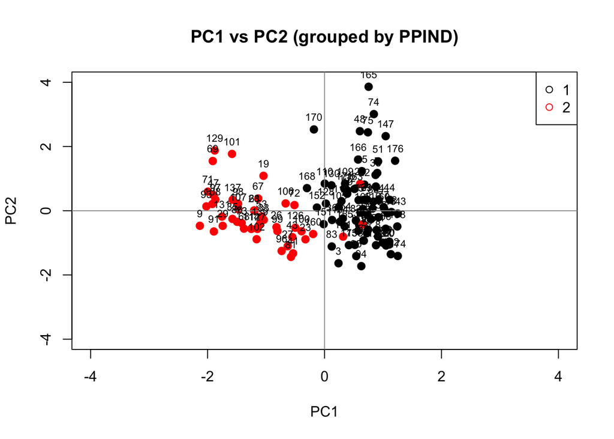

```r
e <- diag(nrow = p)
plot(pca$li[,1]/sqrt(pca$eig[1]), pca$li[,2]/sqrt(pca$eig[2]), pch = 19, cex = 1, lty = "solid", lwd = 2, xlab = "PC1", ylab = "PC2", main = "PC1 vs PC2 (grouped by PPIND)", col = uni$PPIND,  ylim = c(-4,4), xlim = c(-4,4) )
legend('topright',legend = unique(uni$PPIND),col=1:length(uni$PPIND),pch=1)
abline(v = 0, col = "gray60")
abline(h = 0, col = "gray60")
text(pca$li[,1]/sqrt(pca$eig[1]), pca$li[,2]/sqrt(pca$eig[2]), labels = rownames(pca$li), cex= 0.7, pos=3)
```

Видно, что данные неоднородны. PCA находит новые признаки с максимальным разбросом, поэтому здесь лучше всего видно, что частные и государственные университеты различаются.

# Убрали неоднородность

Для начала посмотрим на государственные университеты.

## Собственные числа

Снова посмотрим на график собственных чисел и воспользуемся “правилом сломанной трости”.

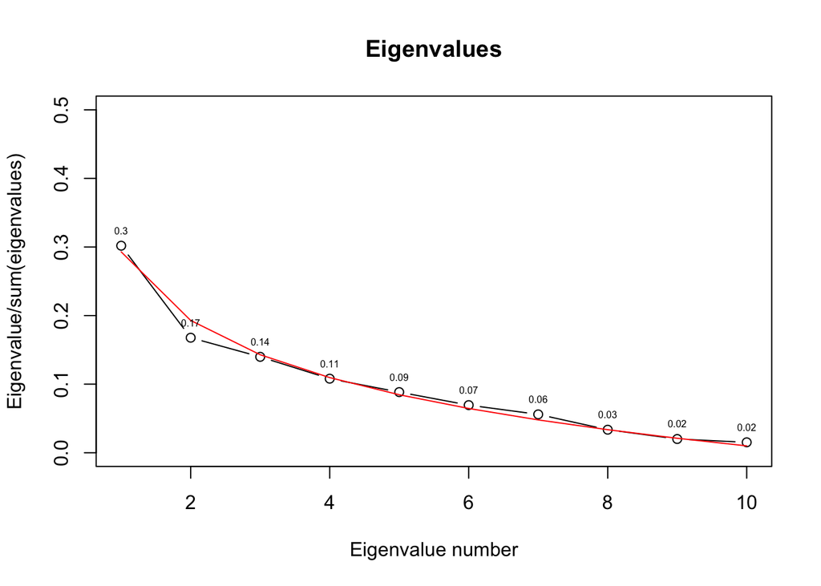

```r
plot(pca$eig/p,  main = "Eigenvalues",  ylab = "Eigenvalue/sum(eigenvalues)", xlab = "Eigenvalue number", type = "b", ylim = c(0,0.5))
lines(EL, col = "red")
text(pca$eig/p, labels =  round(pca$eig/(p), digits = 2), cex= 0.5, pos=3)
```

Правило рекомендует взять только одну главную компоненту, но мы возьмем 2.

```r
summary(pca)
```

```
## Class: pca dudi
## Call: dudi.pca(df = uni.public[, 3:ncol(uni)], scannf = FALSE, nf = p)
##
## Total inertia: 10
##
## Eigenvalues:
##     Ax1     Ax2     Ax3     Ax4     Ax5
##  3.0186  1.6771  1.3982  1.0797  0.8842
##
## Projected inertia (%):
##     Ax1     Ax2     Ax3     Ax4     Ax5
##  30.186  16.771  13.982  10.797   8.842
##
## Cumulative projected inertia (%):
##     Ax1   Ax1:2   Ax1:3   Ax1:4   Ax1:5
##   30.19   46.96   60.94   71.74   80.58
##
## (Only 5 dimensions (out of 10) are shown)
```

Первые 2 главные компоненты объясняют ~47% дисперсии.

## Собственные вектора

Посмотрим на первые 2 собственных вектора корреляционной матрицы:

```r
pca$c1[,1:2]
```

```
##                  CS1         CS2
## NEW10    -0.18587566 -0.34201976
## R_B_COST -0.31753341  0.04428767
## ADD_FEE  -0.09082548 -0.09015193
## BOOK      0.15210439 -0.34622474
## SAL_ALL  -0.43968487 -0.29046683
## NUM_ALL  -0.36173426 -0.32668949
## APP_ACC  -0.40716629 -0.32280369
## SF_RATIO  0.13807112 -0.30868234
## IN_STATE -0.38009813  0.45819420
## OUT_STAT -0.42395835  0.39055884
```

Первую компоненту можно проинтерпретировать как общее качество университета (среднее).

Вторая компонента – соотношение между финансированием и остальными признаками.

## Диаграммы факторных весов

Посмотрим на диаграммы факторных весов.

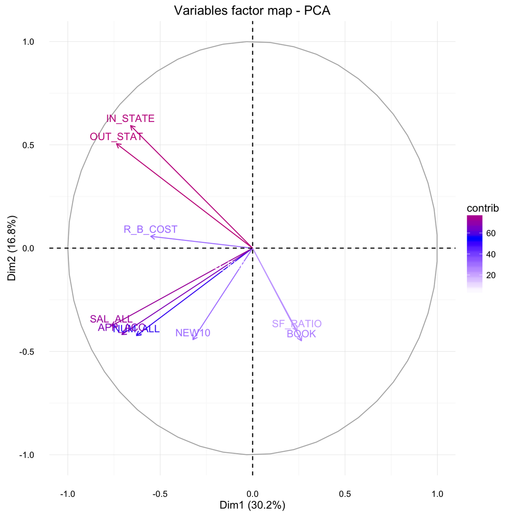

```r
fviz_pca_var(pca, col.var = "contrib")+
scale_color_gradient2(low="white", mid="blue",
      high="red", midpoint=55) + theme_minimal()
```

По картинке можно понять, что государственные университеты тем лучше, чем они больше.

## График нормированных значений главных компонент

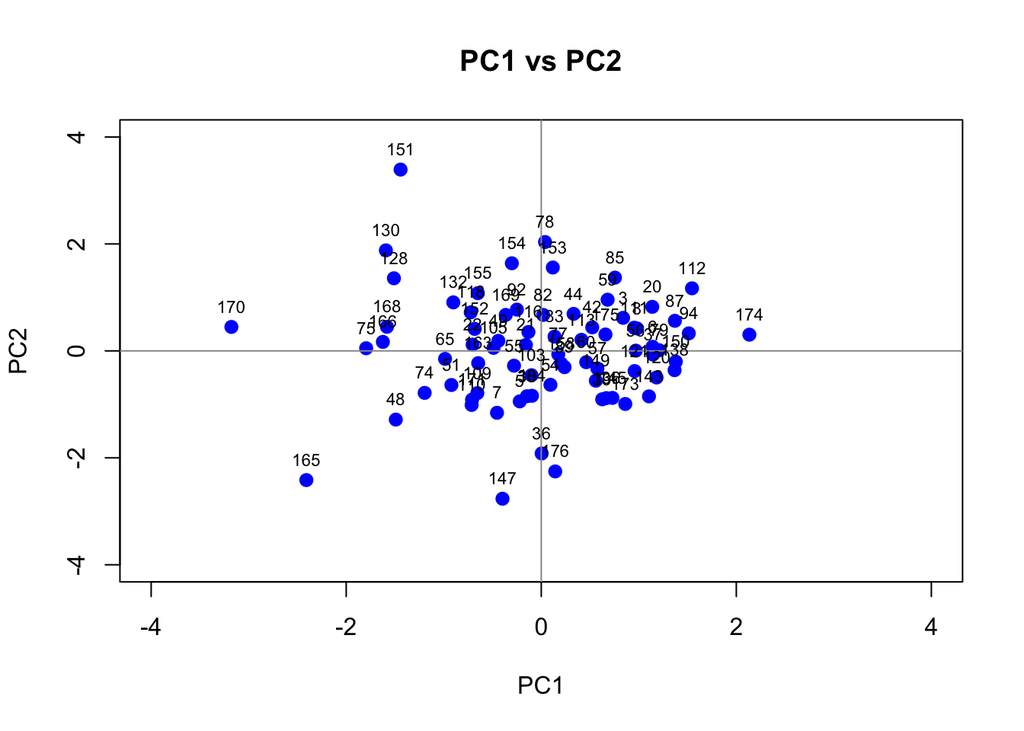

```r
plot(pca$li[,1]/sqrt(pca$eig[1]), pca$li[,2]/sqrt(pca$eig[2]), pch = 19, cex = 1, lty = "solid", lwd = 2, xlab = "PC1", ylab = "PC2", main = "PC1 vs PC2", col = "blue",  ylim = c(-4,4), xlim = c(-4,4))
abline(v = 0, col = "gray60")
abline(h = 0, col = "gray60")
text(pca$li[,1]/sqrt(pca$eig[1]), pca$li[,2]/sqrt(pca$eig[2]), labels = rownames(pca$li), cex= 0.7, pos=3)
```

Посмотрим на частные университеты.

## Собственные числа

Снова воспользуемся “правилом сломанной трости”:

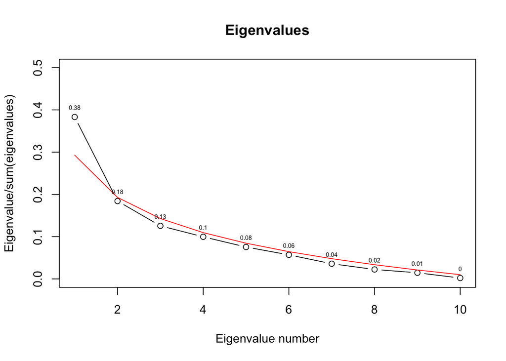

```r
plot(pca$eig/p,  main = "Eigenvalues",  ylab = "Eigenvalue/sum(eigenvalues)", xlab = "Eigenvalue number", type = "b", ylim = c(0,0.5))
lines(EL, col = "red")
text(pca$eig/p, labels =  round(pca$eig/(p), digits = 2), cex= 0.5, pos=3)
```

В этом случае также рекомендуется взять только одну главную компоненту.

```r
summary(pca)
```

```
## Class: pca dudi
## Call: dudi.pca(df = uni.public[, 3:ncol(uni)], scannf = FALSE, nf = p)
##
## Total inertia: 10
##
## Eigenvalues:
##     Ax1     Ax2     Ax3     Ax4     Ax5
##  3.8320  1.8426  1.2561  0.9966  0.7550
##
## Projected inertia (%):
##     Ax1     Ax2     Ax3     Ax4     Ax5
##  38.320  18.426  12.561   9.966   7.550
##
## Cumulative projected inertia (%):
##     Ax1   Ax1:2   Ax1:3   Ax1:4   Ax1:5
##   38.32   56.75   69.31   79.27   86.82
##
## (Only 5 dimensions (out of 10) are shown)
```

Видно, что первые 2 главных компонент объясняют ~57% дисперсии.

## Собственные вектора

Посмотрим на первые 2 собственных вектора корреляционной матрицы:

```r
pca$c1[,1:2]
```

```
##                  CS1         CS2
## NEW10     0.41341039 -0.14727792
## R_B_COST  0.29940828  0.28269421
## ADD_FEE   0.13503060  0.37642698
## BOOK     -0.04277796 -0.17697450
## SAL_ALL   0.39116460  0.01075098
## NUM_ALL   0.20802444  0.57847534
## APP_ACC  -0.09831241  0.58371762
## SF_RATIO -0.33774779  0.15789453
## IN_STATE  0.44631227 -0.13813844
## OUT_STAT  0.44739900 -0.07672984
```

Первая главная компонента – престижность университета.

Вторая главная компонента – размер университета.

## Диаграммы факторных весов

Посмотрим на диаграммы факторных весов.

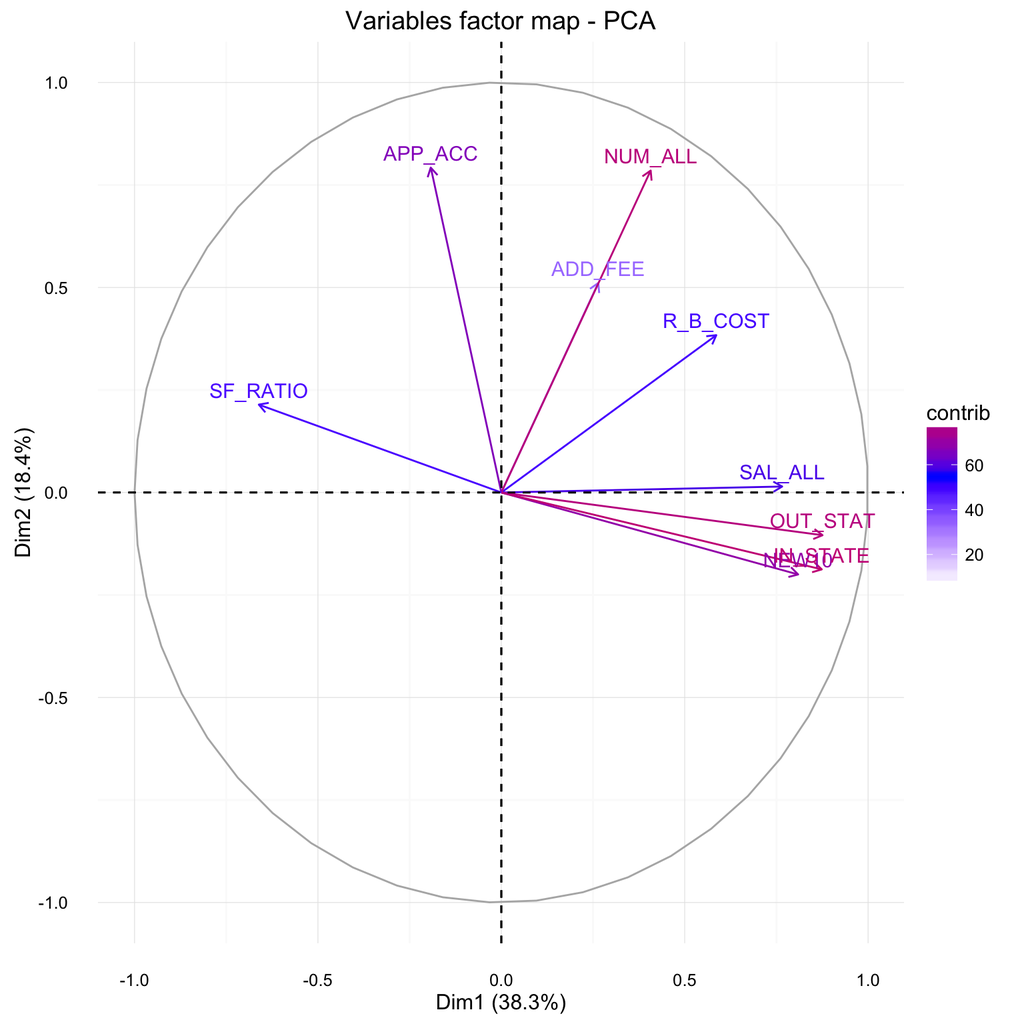

```r
fviz_pca_var(pca, col.var = "contrib")+
scale_color_gradient2(low="white", mid="blue",
      high="red", midpoint=55) + theme_minimal()
```

По картинке видно, что частные университеты устроены по-другому. Размер университета не определяет его качество.

## График нормированных значений главных компонент

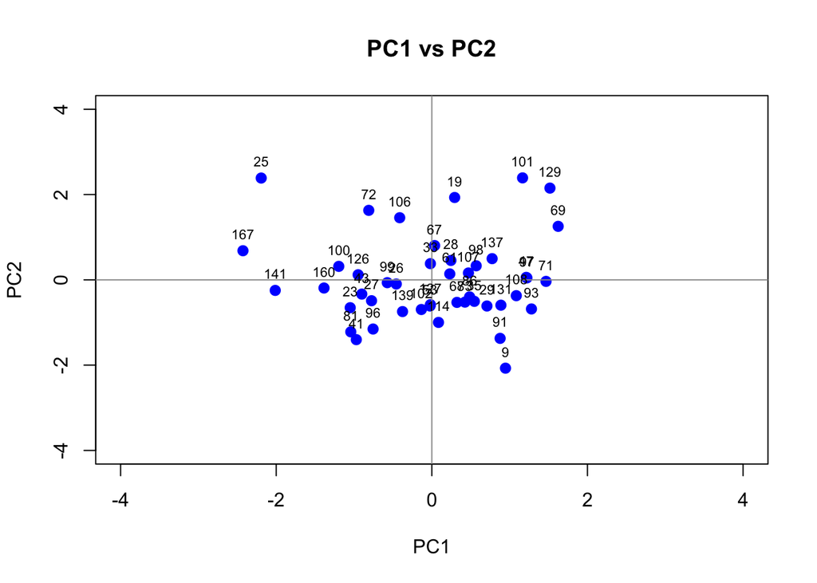

```r
plot(pca$li[,1]/sqrt(pca$eig[1]), pca$li[,2]/sqrt(pca$eig[2]), pch = 19, cex = 1, lty = "solid", lwd = 2, xlab = "PC1", ylab = "PC2", main = "PC1 vs PC2", col = "blue", ylim = c(-4,4), xlim = c(-4,4))
abline(v = 0, col = "gray60")
abline(h = 0, col = "gray60")
text(pca$li[,1]/sqrt(pca$eig[1]), pca$li[,2]/sqrt(pca$eig[2]), labels = rownames(pca$li), cex= 0.7, pos=3)
```